# Monte Carlo approximation to a Categorical CDDM

# Loading Custom Functions

This example requires a single R library: `here`.

```r
# R libraries needed
library(here)
```

All the custom functions written for this project are stored in the `/src/` folder. However, we only need to load the `load_functions.R` file in the `/src/set_up/` subfolder to call the rest of the custom functions in the `/src/` folder.

```r
# Load main loading function
source(here("src/set_up", "load_functions.R"))
load_allCustomFunctions(show=TRUE) # Call the rest of the functions
```

```
##
##  ============================================================
##  LOADING CUSTOM FUNCTIONS FROM:
##   /home/magikarp/Desktop/Adriana/mcmc-tddm/src
## ============================================================
## ----------------------------------------
##  Subdirectory: data_processing
## ----------------------------------------
##   Sourcing: get_categories.R
##   Sourcing: get_choice_in_arc.R
##
## ----------------------------------------
##  Subdirectory: data_sampling
## ----------------------------------------
##   Sourcing: get_data.R
##   Sourcing: sim_auxiliary.R
##   Sourcing: sim_randomWalk.R
##
## ----------------------------------------
##  Subdirectory: estimation
## ----------------------------------------
##   Sourcing: ezcddm.R
##   Sourcing: get_summaryStats.R
##
## ----------------------------------------
##  Subdirectory: macroFunctions
## ----------------------------------------
##   Sourcing: short_routine.R
##
## ----------------------------------------
##  Subdirectory: plotting
## ----------------------------------------
##   Sourcing: plot_auxiliary.R
##   Sourcing: plot_choices.R
##   Sourcing: plot_recovery.R
##
## ----------------------------------------
##  Subdirectory: set_up
## ----------------------------------------
##   Sourcing: complete_parList.R
##   Sourcing: load_functions.R
##
##  All custom functions loaded successfully!
```

# Run a short-demonstration, step by step

## Step 1: Define true parameters

We start by specifying the true parameters used to generate the data under the CDDM. In this first example, we’ll use the same parameters as those [used by the EZCDDM authors in their parameter recovery demonstration](https://github.com/HasanQD/EZ-CDM/blob/main/Simple%20EZ-CDM.ipynb) of the EZCDDM system of equations.

```r
# Arbitrary parameter list
par = list(drift = 2.0, angle = 0.2, boundary = 2, tzero = 0.6)

# Complete the parameter list with the cartesian coordinates
par <- complete_par_list(par)

# Print the parameter list
print(rbind(par))
```

```
##     drift angle boundary tzero mu1      mu2
## par 2     0.2   2        0.6   1.960133 0.3973387
```

## Step 2: Generate data

```r
# Number of trials in the dataset
n = 1000
```

We use our random walk emulator to generate 1000 bivariate observations (choice and RT) from the CDDM, according to the parameters specified in Step 1.

```r
# Look for datafile and load if it exists, otherwise generate new data
data_path = here("output", "mainReport_example1.RData")
data <- load_or_generate_data(data_path, n, par, forceRun = FALSE)
```

```
## Data already exists. Loading datafile...
```

```r
head(data, 10)
```

```
##    Response    RT
## 1    5.8809 1.250
## 2    0.3721 1.989
## 3    0.1760 1.255
## 4    0.3379 1.454
## 5    0.0758 1.255
## 6    6.2733 1.408
## 7    6.0619 1.073
## 8    0.2511 1.588
## 9    0.4741 1.472
## 10   5.5773 1.152
```

## Step 3: Compute parameter estimates

As a reference point, we use the EZCDDM system of equations to obtain parameter estimates from the data generated. This step also helps us to validate our implementation of the EZCDDM forward and backward system of equations.

```r
# Compute summary statistics from the data generated in Step 2
sumstats <- get_summaryStats(angular_vector = data$Response, rt_vector = data$RT)

# Compute parameter estimates using these summary statistics
ez <- ezcddm_getParameters(sumstats)

# Combine the true parameters with the EZCDDM parameter estimates
results <- as.data.frame(rbind(c(par$drift, par$boundary, par$tzero, par$angle),
                               c(ez$drift_length, ez$bound, ez$ndt, ez$drift_angle)))
colnames(results) <- c("Drift_length", "Boundary", "Non-decision_time", "Drift_angle")
rownames(results) <- c("True", "EZCDDM")
round(results, 4)
```

```
##        Drift_length Boundary Non-decision_time Drift_angle
## True         2.0000   2.0000            0.6000      0.2000
## EZCDDM       2.0287   1.9785            0.6241      0.2109
```

## Step 4: Convert angular choices to categorical responses

The categorical extension of the CDDM is conceptually built on the addition of a set of cut points along the circular response space to define arcs of the circumference that represent identical responses (i.e., a categorical response).

We use the data we generated from the standard CDDM model to fabricate categorical responses by looking at which arcs the choices fall into.

In our approximation, we assume that the number of categories is known and that they are equally spaced on the circumference. For this first example, we start with 4 cut points to define 4 categories (labeled as A, B, C, D).

```r
# Number of categories
nCat = 4

# Obtain category labels
categories = LETTERS[1:nCat]   # Obtaining category labels
print(categories)
```

```
## [1] "A" "B" "C" "D"
```

```r
# Obtain cut points for the categories (equally spaced on the circle; remove the closed point)
cut_points = seq(0, 2*pi, length.out = nCat+1)[-(nCat+1)]
print(round(cut_points, 3))
```

```
## [1] 0.000 1.571 3.142 4.712
```

Then, we use our `get_categorical_choices` custom function to convert the angular choices generated from the CDDM into categorical responses, depending on which arc of the circumference they fall into.

```r
# Convert choices to categorical values
data <- get_categorical_choices(data, cut_points, categories)
head(data, 10)
```

```
##    Response    RT Category
## 1    5.8809 1.250        D
## 2    0.3721 1.989        A
## 3    0.1760 1.255        A
## 4    0.3379 1.454        A
## 5    0.0758 1.255        A
## 6    6.2733 1.408        D
## 7    6.0619 1.073        D
## 8    0.2511 1.588        A
## 9    0.4741 1.472        A
## 10   5.5773 1.152        D
```

As such, the data used for this example looks like:

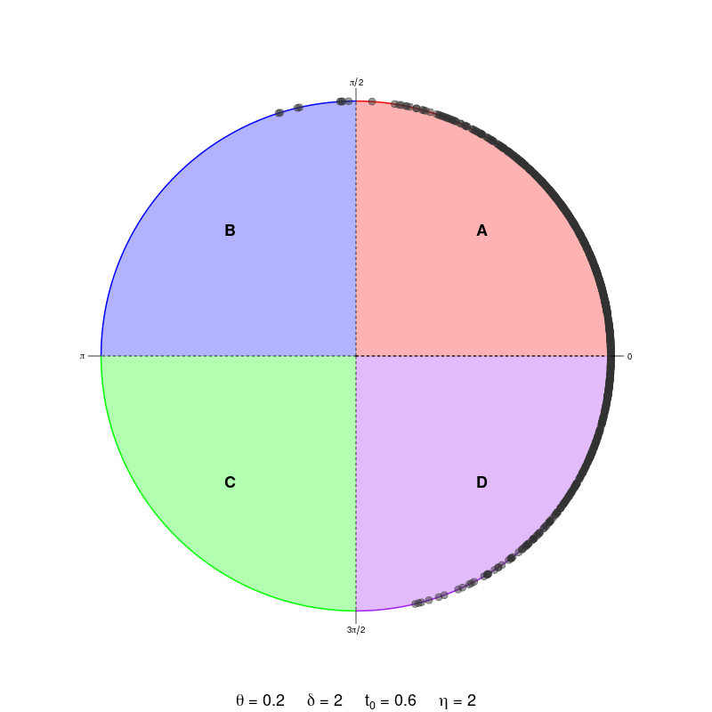

## Step 5: Monte Carlo approximation to the categorical CDDM

```r
# Number of iterations for the Monte Carlo approximation
nIter = 1000
```

We run the Monte Carlo approximation over 1000 iterations. In each iteration, we:

1. Ignore the actual angular choices generated from the CDDM
2. Look at the ‘categorical choices’ and replace them with a random angle falling within the corresponding arc
3. Use the EZCDDM system of equations to estimate the parameters from the resulting dataset

By repeating the process 1000 times, we obtain a distribution of parameter estimates for every dataset generated.

```r
# Initialize a matrix to store the parameter estimates
estimates <- matrix(NA, nrow = nIter, ncol = 4)

# Loop over the number of iterations
for(i in 1:nIter){
    set.seed(i) # Set seed for reproducibility
    tmp <- get_choice_in_arc(data, cut_points, categories)
    tmp_sumstats <- get_summaryStats(angular_vector = tmp$Sim_choice, rt_vector = tmp$RT)
    tmp_estimates <- ezcddm_getParameters(tmp_sumstats)
    estimates[i, ] <- c(tmp_estimates$drift_length, tmp_estimates$bound, tmp_estimates$ndt, tmp_estimates$drift_angle)
}
```

We look at the average parameter estimates obtained across all iterations.

```r
update_results <-rbind(results, apply(estimates, 2, mean))
rownames(update_results) <- c(rownames(results), "MC-EZCDDM")

print(update_results)
```

```
##           Drift_length Boundary Non-decision_time Drift_angle
## True          2.000000 2.000000         0.6000000   0.2000000
## EZCDDM        2.028680 1.978511         0.6241382   0.2108793
## MC-EZCDDM     1.340247 1.329013         0.8146577   0.3111037
```

The mean parameter estimates obtained from the Monte Carlo approximation are not doing a good job of recovering the true parameters. We know the problem is not in our implementation of the EZCDDM system of equations, because the parameter estimates obtained from the data simulated from the actual model are very close to the true parameters.

In the following sections, we continue to explore our Monte Carlo approximation by trying different numbers of categorias, trial size, Monte Carlo iterations, and different parameter values.

# Increase the number of categories

Looking at the circular choice plot presented on our first example, we see that most choices fall into two categories. Despite angular choices following a von Mises distribution, our Monte Carlo approximation generates angles within the arcs covering half of the circumference with equal probability.

In this section, we present a more extreme scenario where we test our Monte Carlo approximation with an increased number of categories.

```r
# Number of categories
nCat = 16

sample2 <- run_short_MCroutine(n = n, nCat = nCat, nIter = nIter, show=FALSE,
                               data_path = data_path,
                               forceRun = FALSE,
                               par = par,
                               fig1_path = here("output", "figures", "mainReport_example2_data.png"),
                               fig2_path = here("output", "figures", "mainReport_example2_recovery.png"))
```

```
## Data already exists. Loading datafile...
```

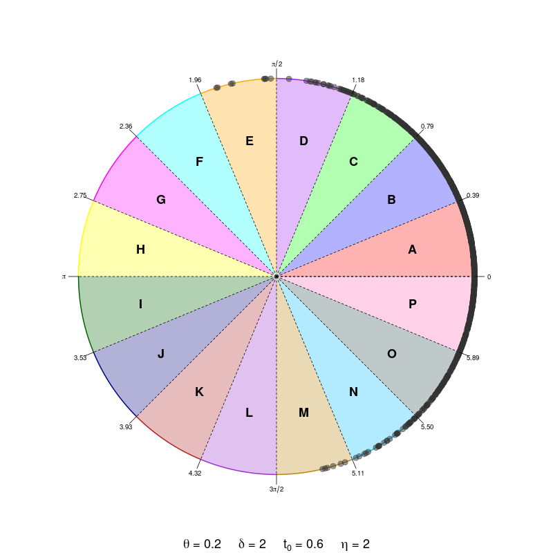

```r
print(sample2)
```

```
##           Drift_length Boundary Non-decision_time Drift_angle
## True          2.000000 2.000000         0.6000000   0.2000000
## EZCDDM        2.028700 1.978500         0.6241000   0.2109000
## MC-EZCDDM     1.967319 1.882672         0.6523396   0.2089793
```